# Model Estimation without Share Data

Katsuhiro Komatsu

2021-04-11

### Parameter Estimates

#### 1. Estimating $\alpha, \lambda^W, \lambda^F$ and other linear parameters

Non-linear Parameters

| Parameter | Est. | S.E. |
| --- | --- | --- |
| alpha | 0.511 | 51.943 |
| lambda_W | 0.112 | 11.421 |
| lambda_F | 0.107 | 11.408 |

Linear Parameters

| Variables | Coef. | S.E. |
| --- | --- | --- |
| daily | 0.122 | 0.019 |
| shokai | 0.288 | 0.018 |
| oversea | 0.731 | 0.085 |
| cocurrent | 0.216 | 0.020 |

Implied Price Impact

| Variables | Coef. | Elasticity |
| --- | --- | --- |
| Net Wage | 4.557 | 1.151 |
| Net Fee | -4.549 | -3.553 |

#### 2. Excluding $\alpha$ from the estimation

Non-linear Parameters

| Parameter | Est. | S.E. |
| --- | --- | --- |
| lambda_W | 0.220 | 0.028 |
| lambda_F | 0.067 | 0.008 |

Linear Parameters

| Variables | Coef. | S.E. |
| --- | --- | --- |
| daily | 0.230 | 0.016 |
| shokai | 0.327 | 0.015 |
| oversea | 0.516 | 0.057 |
| cocurrent | 0.340 | 0.014 |

### Decomposing (Semi) Elasticities

Application Semi-Elasticities

| Parameter | Estimates |
| --- | --- |
| Direct (Wage) | 4.550 |
| Network (Wage) | -2.171 |
| Application (Fee) | 14.851 |
| Network (Fee) | -4.230 |

Match Semi-Elasticities

| Parameter | Estimates |
| --- | --- |
| Direct (Wage) | 2.794 |
| Network (Wage) | 1.764 |
| Application (Fee) | 2.792 |
| Network (Fee) | 1.757 |

# Distribution of Platform Heterogeneity $a_i$

- Unit: 10K Yen
  - Normalization: Direct employment $a_0=0$
  - This does not depend on the assumption on the matching parameters.

### Distribution of $a_i$

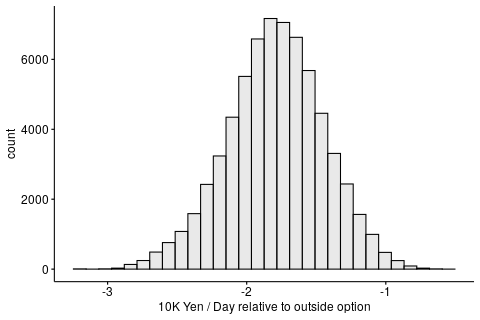

### Distribution of Market FE

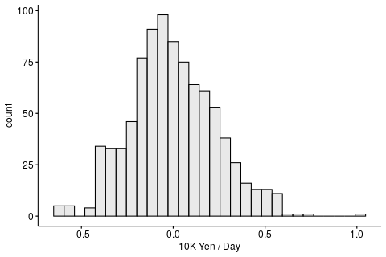

### Distribution of Firm FE

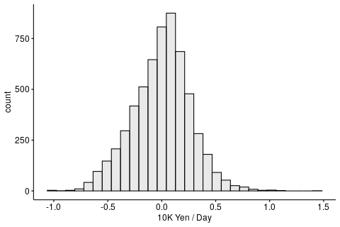

### Market FE vs Market Size

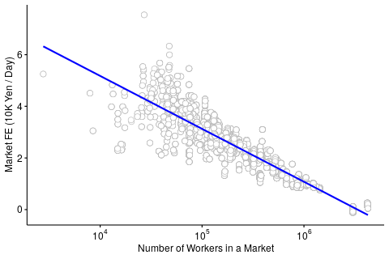

## Marginal Cost

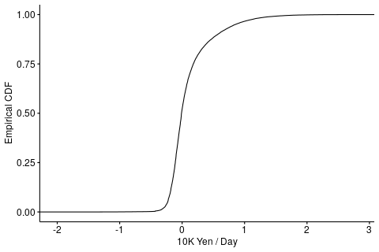

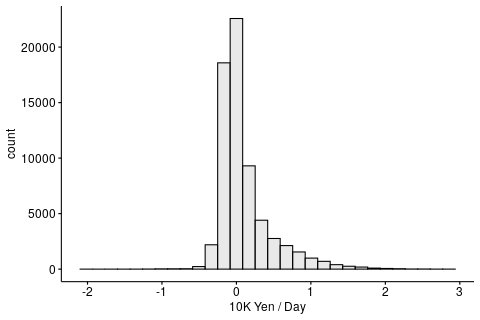

# Model Fit

### Wage

- $R^2$ of regressing actual data on simulated data: 0.013

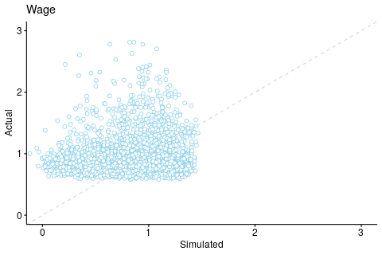

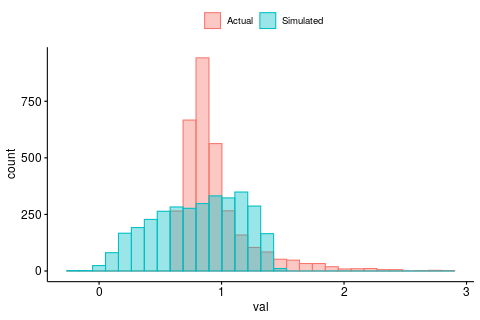

### Fee

- $R^2$ of regressing actual data on simulated data: 0.326

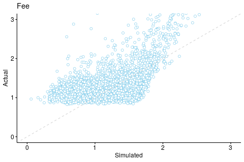

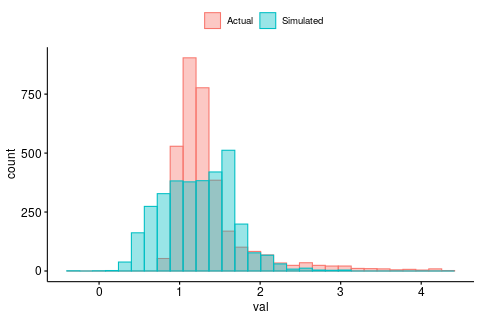

### Margin

- margin = $log(fee)-log(wage)$
- $R^2$ of regressing actual data on simulated data: 0.228

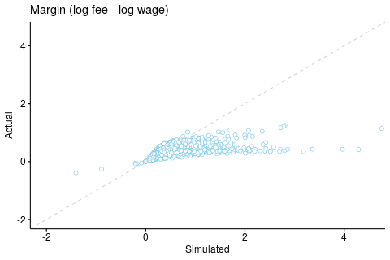

### Match

- Log of the number of matches relative to outside option $log{(q/q_0)}$
- $R^2$ of regressing actual data on simulated data: 0.44

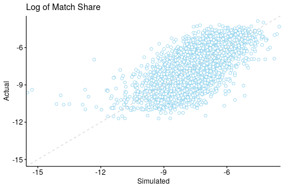

## Aggregate

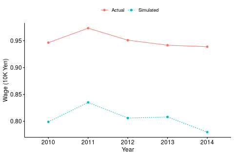

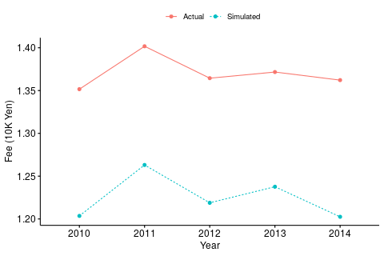

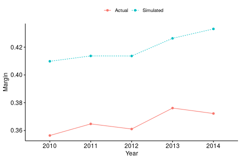

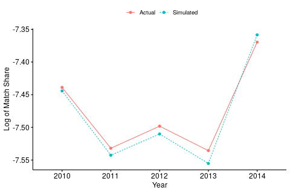

## Imposing Minimum Wage

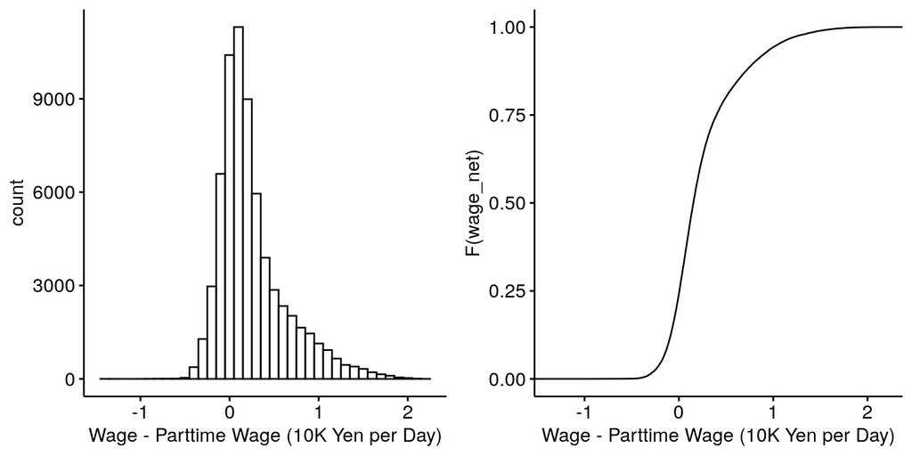

### Distribution of Actual Wage - Minimum Wage

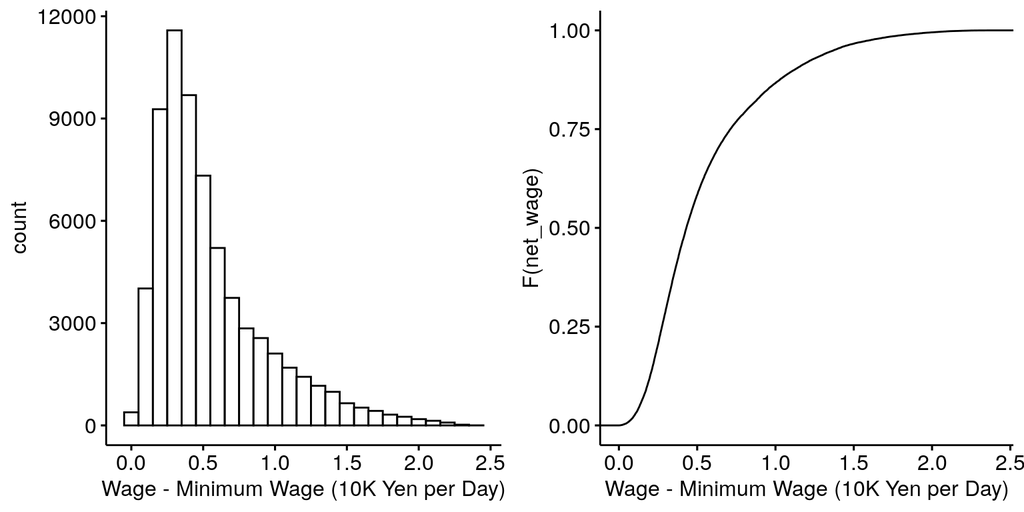

### Wage

- $R^2$ of regressing actual data on simulated data: 0.013
- $R^2$ of regressing actual data on simulated data with minimum wage constraint: 0.01

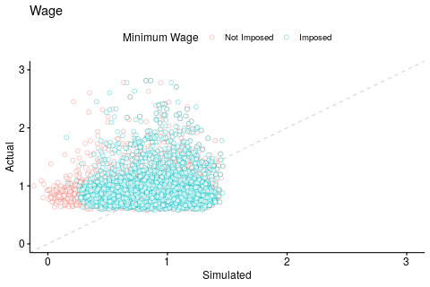

### Fee

- $R^2$ of regressing actual data on simulated data: 0.326
- $R^2$ of regressing actual data on simulated data with minimum wage constraint: 0.396

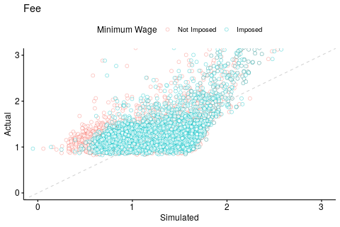

### Margin

- margin = $log(fee)-log(wage)$
- $R^2$ of regressing actual data on simulated data: 0.228
- $R^2$ of regressing actual data on simulated data with minimum wage constraint: 0.4

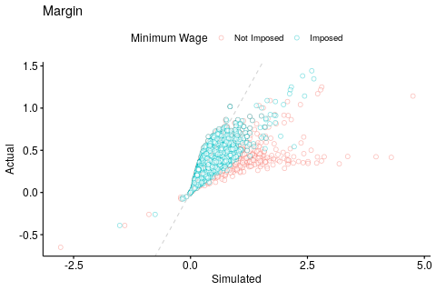

### Match

- Log of the number of matches relative to outside option $log{(q/q_0)}$
- $R^2$ of regressing actual data on simulated data: 0.44
- $R^2$ of regressing actual data on simulated data with minimum wage constraint: 0.459

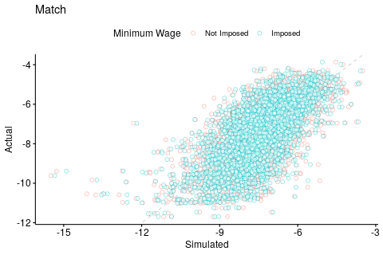

## Aggregate

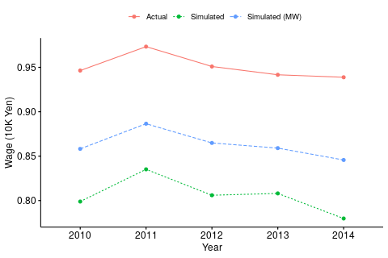

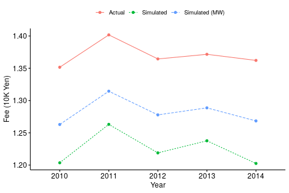

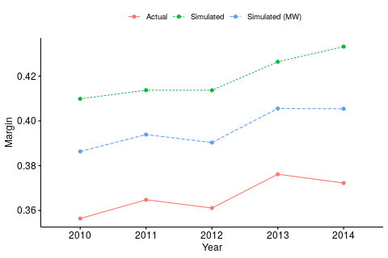

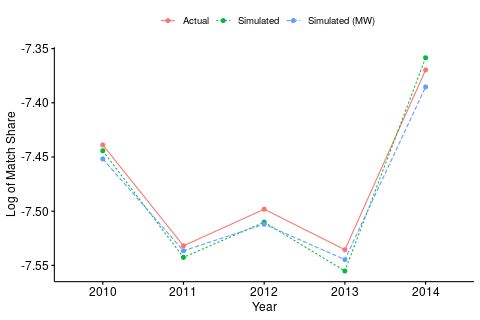